# CLASS PROJECT

## Setup

Execute the following cell to get this notebook into a two column format.

```python
%%html
<style>
div.cell{
         box-orient:horizontal;
         flex-direction:row;
}

div.cell *{
         width:100%;
}

div.prompt{
          width:80px;

}
</style>
```

And the following code let's us see plots in the notebook.

```python
%matplotlib inline
```

Restarting the iPython kernel to reset your environment:

1. Kernel>restart>restart
2. Cell>Run All

We will use this bit of JavaScript to show answers to questions on clicking

```python
%%javascript
function toggle_visibility(id) {
   var e = document.getElementById(id);
   if(e.style.display == 'block')
      e.style.display = 'none';
   else
      e.style.display = 'block';
}
```

# Problem Description

*Reference*: Alon, Uri, Network motifs: theory and experimental approaches. Nature Reviews Genetics, jun, vol 8, no 6, 2007, pp. 450--61.

**QUESTION**: What is the gene network diagram for this model?

# The Diagram

[figure not shown]

# Building the model

## Y1 and Z1

We'll start by modeling Z1. This is produced by a I1-FFL that inputs X1 (which is activated by the starvation signal). This I1-FFL produces Y1 and expresses Z1. So, we need two genes. G0 expresses Y1, and G1 expresses Z1. For each gene, there is an upstream promoter.

**QUESTION**: What is the antimony code to express this DNA strand?

```
dna1: --P0--G0--P1--G1--
```

We will model the expression of Y1 by having X1 bind to P0.

**PROBLEM**: We denote the maximum velocity of this reaction by Vmax0. Write the antimony code that describes the relevant reactions. Don't forget to include the degradation of Y1, and use gamma_0 as the reaction rate for the degradation.

```
// X1 is the input signal

// Must precede other assignments
dna1: --P0--G0--P1--G1--

// Z1 = FFL-I1(X1). P0/G0, P1/G1.
//   Y1
P0 = Vmax0*X1^6/(1 + a1*X1^6);
G0: -> Y1;
Y1 -> ; gamma_0*Y1  // Y1 degrades
```

**PROBLEM**: Create a python program that simulates Y1. Initially, X1 is not present. At 5s, X1 is 5M (because of the response to the starvation signal). Then, run the program in the cell.

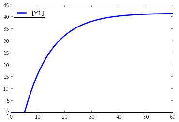

```
<module 'matplotlib.pyplot' from '/usr/lib/pymodules/python2.7/matplotlib/pyplot.pyc'>
```

```python
import numpy
import tellurium as te

antStr = '''
// X1 is the input signal

// Precedes other statements
dna1: --P0--G0--


//   Y1
P0 = Vmax0*X1/(1 + X1);
G0: -> Y1;
Y1 -> ; gamma_0*Y1  // Y1 degrades

gamma_0 = 0.1;
Vmax0 = 5;
X1 = 0; Y1 = 0;

at (time >5): X1 = 5
'''

r = te.loadAntimonyModel(antStr)
model = r.simulate(0, 60, 500)
te.plotWithLegend(r, numpy.vstack ((model)))
```

Note that the antimony event at (time >5): X1 = 5 provides a way to change the concentration of X1.

**QUESTION**: What can you do to the model to make the response time faster? Change the model for P0 to do this.

ANSWER

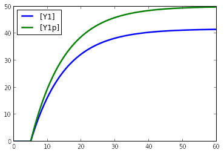

```
<module 'matplotlib.pyplot' from '/usr/lib/pymodules/python2.7/matplotlib/pyplot.pyc'>
```

```python
import numpy
import tellurium as te

antStr = '''
// X1 is the input signal

// Precedes other statements
dna1: --P0--G0--P0p--G0p--


// Y1
P0 = Vmax0*X1/(1 + X1);
G0: -> Y1;
D0: Y1 -> ; gamma_0*Y1  // Y1 degrades

gamma_0 = 0.1;
Vmax0 = 5;
X1 = 0; Y1 = 0;


// Y1p
P0p = Vmax0*X1^6/(1 + X1^6);
G0p: -> Y1p;
Y1p -> ; gamma_0*Y1p  // Y1p degrades

gamma_0 = 0.1;
Vmax0 = 5;

at (time >5): X1 = 5
'''

r = te.loadAntimonyModel(antStr)
model = r.simulate(0, 60, 500)
te.plotWithLegend(r, numpy.vstack ((model)))
```

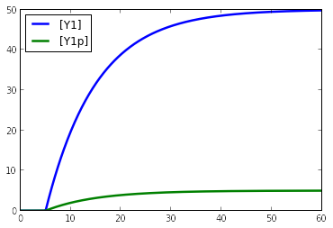

```
<module 'matplotlib.pyplot' from '/usr/lib/pymodules/python2.7/matplotlib/pyplot.pyc'>
```

```python
import numpy
import tellurium as te

antStr = '''
// X1 is the input signal

// Precedes other statements
dna1: --P0--G0--P0p--G0p--


//   Y1
P0 = Vmax0*X1^6/(1 + X1^6);
G0: -> Y1;
Y1 -> ; gamma_0*Y1  // Y1 degrades

//   Y1p with a scale factor
P0p = Vmax0*X1^6/(1 + a1*X1^6);
G0p: -> Y1p;
Y1p -> ; gamma_0*Y1p  // Y1 degrades

a1 = 10;
gamma_0 = 0.1;
Vmax0 = 5;
X1 = 0; Y1 = 0;

at (time >5): X1 = 5
'''

r = te.loadAntimonyModel(antStr)
model = r.simulate(0, 60, 500)
te.plotWithLegend(r, numpy.vstack ((model)))
```

Next we compute Z1, the output signal of the I1-FFL. This requires a second gene and reaction kinetics that result in Z1 = X1 AND NOT Y1.

**PROBLEM**: Write additional antimony code that implements this logic.

```python
import numpy
import tellurium as te

antStr = '''

// X1 is the input signal

// Must precede other assignments
dna1: --P0--G0--P1--G1--


// Z1 = FFL-I1(X1). P0/G0, P1/G1.
//   Y1
P0 = Vmax0*X1^6/(1 + a1*X1^6);
G0: -> Y1;
Y1 -> ; gamma_0*Y1  // Y1 degrades

//  Z1 = X1 AND NOT Y1
P1 = Vmax1*b1*X1/(1 + b1*X1 + b2*Y1 + b3*X1*Y1^4);
G1: -> Z1;
Z1 -> ; gamma_1*Z1  // Z1 degrades

a1 = 10; b1 = 0.1; b2 = 0.1; b3 = 0.1;
gamma_0 = 0.1; gamma_1 = 0.1
Vmax0 = 5; Vmax1 = 12;
X1 = 0; Y1 = 0; Z1 = 0;

at (time >5): X1 = 5
'''

r = te.loadAntimonyModel(antStr)
model = r.simulate(0, 60, 500)
te.plotWithLegend(r, numpy.vstack ((model)))
```

[output not shown]

```
<module 'matplotlib.pyplot' from '/usr/lib/pymodules/python2.7/matplotlib/pyplot.pyc'>
```

ANSWER

The code is getting longer, and soon it may be difficult to focus on the new code that we add.

We need to structure the code so that we can identify the source of problems (e.g., bugs in models) and identify where changes are required if new features are to be implemented.

Since the antimony code is a python string, we can structure the code into separate python strings. Below is such a restructuring of the code we wrote to model Y1 and Z1.

```python
antStr_Y1 = '''

// X1 is the input signal

// Must precede other assignments
dna1: --P0--G0--P1--G1--


// Z1 = FFL-I1(X1). P0/G0, P1/G1.
//   Y1
P0 = Vmax0*X1^6/(1 + a1*X1^6);
G0: -> Y1;
Y1 -> ; gamma_0*Y1  // Y1 degrades

a1 = 10;
Vmax0 = 5;
X1 = 0; Y1 = 0;
'''


antStr_Z1 = '''

//  Z1 = X1 AND NOT Y1
P1 = Vmax1*b1*X1/(1 + b1*X1 + b2*Y1 + b3*X1*Y1^4);
G1: -> Z1;
Z1 -> ; gamma_1*Z1  // Z1 degrades

b1 = 0.1; b2 = 0.1; b3 = 0.1;
gamma_0 = 0.1; gamma_1 = 0.1
Vmax1 = 12;
Z1 = 0;

at (time >5): X1 = 5
'''


import numpy
import tellurium as te
antStr = antStr_Y1 + antStr_Z1
r = te.loadAntimonyModel(antStr)
model = r.simulate(0, 60, 500)
te.plotWithLegend(r, numpy.vstack ((model)))
```

[output not shown]

```
<module 'matplotlib.pyplot' from '/usr/lib/pymodules/python2.7/matplotlib/pyplot.pyc'>
```

The above code is structured into three parts:

1. Code the produces Y1
2. Code the produces Z1
3. Python "wrapper" that executes #1 and #2.

   We can define antimony code in one cell and then use it in a subsequent cell.However, you have to execute the cell before the string is defined (such as antStr_Y1). Below is an example. Note that we have a separate string for the DNA strand since this is something that we'll want to modify to incorporate more genes.

```python
antStr_dna = 'dna1: --P0--G0--P1--G1--'
```

```python
antStr_Y1 = '''

// Y1
P0 = Vmax0*X1^6/(1 + a1*X1^6);
G0: -> Y1;
Y1 -> ; gamma_0*Y1  // Y1 degrades

a1 = 10;
Vmax0 = 5;
X1 = 0; Y1 = 0;
'''
```

```python
antStr_Z1 = '''

//  Z1 = X1 AND NOT Y1
P1 = Vmax1*b1*X1/(1 + b1*X1 + b2*Y1 + b3*X1*Y1^4);
G1: -> Z1;
Z1 -> ; gamma_1*Z1  // Z1 degrades

b1 = 0.1; b2 = 0.1; b3 = 0.1;
gamma_0 = 0.1; gamma_1 = 0.1
Vmax1 = 12;
Z1 = 0;

at (time > 5): X1 = 5
'''

import numpy
import tellurium as te
antStr = (antStr_dna + antStr_Y1 + antStr_Z1
          )
r = te.loadAntimonyModel(antStr)
model = r.simulate(0, 60, 500)
te.plotWithLegend(r, numpy.vstack ((model)))
```

[output not shown]

```
<module 'matplotlib.pyplot' from '/usr/lib/pymodules/python2.7/matplotlib/pyplot.pyc'>
```

We'll treat antStr_Z1 in the same way as antStr_Y1. That is, we'll define and execute it in a separate cell. Then, we'll work on X2.

```python
antStr_Z1 = '''

//  Z1 = X1 AND NOT Y1
P1 = Vmax1*b1*X1/(1 + b1*X1 + b2*Y1 + b3*X1*Y1^4);
G1: -> Z1;
Z1 -> ; gamma_1*Z1  // Z1 degrades

b1 = 0.1; b2 = 0.1; b3 = 0.1;
gamma_0 = 0.1; gamma_1 = 0.1
Vmax1 = 12;
Z1 = 0;
'''
```

```python
antStr_ev = '''
at (time >5): X1 = 5
'''
```

```python
antStr_X2 = '''
'''
import numpy
import tellurium as te
antStr = (antStr_dna + antStr_Y1 + antStr_Z1
          + antStr_X2 + antStr_ev)
r = te.loadAntimonyModel(antStr)
model = r.simulate(0, 60, 500)
te.plotWithLegend(r, numpy.vstack ((model)))
```

[output not shown]

```
<module 'matplotlib.pyplot' from '/usr/lib/pymodules/python2.7/matplotlib/pyplot.pyc'>
```

**QUESTION**: What code was added to the python wrapper so that executing the above cell will include antStr_X2?

ANSWER

**QUESTION**: Which strings must be modified to model the expression of X2?

ANSWER

**PROBLEM**: Do the modifications needed to express X2, including the addition of another gene and promoter.

```python
antStr_dna = '''

dna1: --P0--G0--P1--G1--P2--G2--

'''
```

```python
antStr_X2 = '''

// X2 = X1 AND Y1. P2/G2.
P2numr = Vmax2*X1^10*Y1^10;
P2denom = 1 + c1*X1^10 + c2*Y1^10 + c3*X1*Y1^10;
P2 = P2numr / P2denom;
P2 = Vmax2*X1^10*Y1^10/(1 + c1*X1^10 + c2*Y1^10 + c3*X1*Y1^10);
G2: -> X2;
X2  -> ; gamma_2*X2

c1 = 4.5; c2 = 15; c3 = 10.95;
gamma_2 = 2
Vmax2 = 0.00008;
X2 = 0;
'''
```

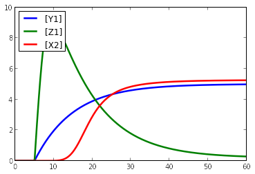

```
<module 'matplotlib.pyplot' from '/usr/lib/pymodules/python2.7/matplotlib/pyplot.pyc'>
```

```python
import numpy
import tellurium as te
antStr = (antStr_dna + antStr_Y1 + antStr_Z1
          + antStr_X2 + antStr_ev)
r = te.loadAntimonyModel(antStr)
model = r.simulate(0, 60, 500)
te.plotWithLegend(r, numpy.vstack ((model)))
```

Z2 is expressed as a I1-FFL with X2.

**QUESTION**: How many genes must be added to express Z2?

ANSWER

**QUESTION**: Write the kinetics equation for the promoter for the gene that expresses Z2. Use the constants Vmax4, d1, d2, d3, gamma_4. Use an exponent of 4 for X2 and Y2.

ANSWER

**PROBLEM**: Write the antimony code to compute Z2, extending the python wrapper as required.

```python
antStr_dna = '''

dna1: --P0--G0--P1--G1--P2--G2--P3--G3--P4--G4--

'''
```

```python
antStr_Z2 = '''

// Y2. P3/G3.
P3 = Vmax3*X2^4/(1 + f1*X2^4);
G3: -> Y2;
Y2 -> ; gamma_3*Y2

f1 = 5;
gamma_3 = 0.75;
Vmax3 = 22;
Y2 = 0;


// Z2 = X2 AND NOT Y2. P4/G4.
P4 = Vmax4*d1*X2^4/(1 + d1*X2^4 + d2*Y2^4 + d3*X2^4*Y2^4);
P4 = Vmax4*d1*X2^4/(1 + d1*X2^4 + d2*Y2^4 + d3*X2^4*Y2^4);
G4: -> Z2;
Z2 -> ; gamma_4*Z2

d1 = 1; d2 = 0.1; d3 = 5;
gamma_4 = 0.6;
Vmax4 = 140;
Z2 = 0;
'''
```

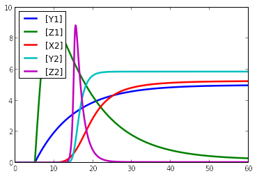

```
<module 'matplotlib.pyplot' from '/usr/lib/pymodules/python2.7/matplotlib/pyplot.pyc'>
```

```python
import numpy
import tellurium as te
antStr = (antStr_dna + antStr_Y1 + antStr_Z1
          + antStr_X2 + antStr_Z2 + antStr_ev)
r = te.loadAntimonyModel(antStr)
model = r.simulate(0, 60, 500)
te.plotWithLegend(r, numpy.vstack ((model)))
```

**PROBLEM**: Implement the model extensions needed to express Z3.

```python
antStr_dna = '''

dna1: --P0--G0--P1--G1--P2--G2--P3--G3--P4--G4--P5--G5--

'''
```

```python
antStr_Z3 = '''

// Z3 = X2 AND Y2
P5 = Vmax5*X2^10*Y2^10/(1 + g1*X2^10 + g2*Y2^10 + g3*X2*Y2^10);
G5: -> Z3;
Z3 -> ; gamma_5*Z3

g1 = 20; g2 = 25; g3 = 10.95;
gamma_5 = 2;
Vmax5 = 0.00006;
Z3 = 0;

'''
```

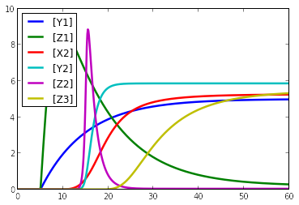

```
<module 'matplotlib.pyplot' from '/usr/lib/pymodules/python2.7/matplotlib/pyplot.pyc'>
```

```python
import numpy
import tellurium as te
antStr = (antStr_dna + antStr_Y1 + antStr_Z1
          + antStr_X2 + antStr_Z2 + antStr_Z3 + antStr_ev)
r = te.loadAntimonyModel(antStr)
model = r.simulate(0, 60, 500)
te.plotWithLegend(r, numpy.vstack ((model)))
```

## Complete Code

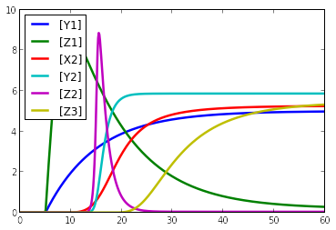

```
<module 'matplotlib.pyplot' from '/usr/lib/pymodules/python2.7/matplotlib/pyplot.pyc'>
```

```python
import numpy
import tellurium as te

antStr = '''

// X1 is the input signal

// Must precede other assignments
dna1: --P0--G0--P1--G1--P2--G2--P3--G3--P4--G4--P5--G5--


// Z1 = FFL-I1(X1). P0/G0, P1/G1.
//   Y1
P0 = Vmax0*X1^6/(1 + a1*X1^6);
G0: -> Y1;
Y1 -> ; gamma_0*Y1  // Y1 degrades

//  Z1 = X1 AND NOT Y1
P1 = Vmax1*b1*X1/(1 + b1*X1 + b2*Y1 + b3*X1^1*Y1^4);
G1: -> Z1;
Z1 -> ; gamma_1*Z1  // Z1 degrades

a1 = 10; b1 = 0.1; b2 = 0.1; b3 = 0.1;
gamma_0 = 0.1; gamma_1 = 0.1
Vmax0 = 5; Vmax1 = 12;
X1 = 0; Y1 = 0; Z1 = 0;


// X2 = X1 AND Y1. P2/G2.
P2 = Vmax2*X1^10*Y1^10/(1 + c1*X1^10 + c2*Y1^10 + c3*X1*Y1^10);
G2: -> X2;
X2 -> ; gamma_2*X2

c1 = 4.5; c2 = 15; c3 = 10.95;
gamma_2 = 2
Vmax2 = 0.00008;
X2 = 0;


// Z2 = FFL-I1(X2). P3/G3, P4/G4.
//   Y2
P3 = Vmax3*X2^4/(1 + f1*X2^4);
G3: -> Y2;
Y2 -> ; gamma_3*Y2

//  Z2 = X2 AND NOT Y2
P4 = Vmax4*d1*X2^4/(1 + d1*X2^4 + d2*Y2^4 + d3*X2^4*Y2^4);
G4: -> Z2;
Z2 -> ; gamma_4*Z2

f1 = 5; d1 = 1; d2 = 0.1; d3 = 5;
gamma_3 = 0.75; gamma_4 = 0.6;
Vmax3 = 22; Vmax4 = 140;
Y2 = 0; Z2 = 0;


// Z3 = X2 AND Y2
P5 = Vmax5*X2^10*Y2^10/(1 + g1*X2^10 + g2*Y2^10 + g3*X2*Y2^10);
G5: -> Z3;
Z3 -> ; gamma_5*Z3

g1 = 20; g2 = 25; g3 = 10.95;
gamma_5 = 2;
Vmax5 = 0.00006;
Z3 = 0;

at (time > 5): X1 = 5;
'''


r = te.loadAntimonyModel (antStr)
model = r.simulate(0, 60, 500)
te.plotWithLegend (r, numpy.vstack ((model)))
```